# Tarea1_Ricardo_Garbanzo

Ricardo Garbanzo

3/7/2020

#### 1. El archivo bosques energia.csv el cual contiene el resultado de dos estudios, uno en el que se mide la supercie boscosa en proporcion al terreno total de cada pais y el otro corresponde al consumo de energia renovable en proporcion al consumo de energia total. Estos estudios se hicieron en varios paises y en varios anos distintos. Con estos datos realize lo siguiente:

### a) (10 pts) Convierta los datos a datos tidy.

```r
library(tidyr)
datos <- read.csv("bosques_energia.csv", header = T, sep = ",")
#datos <- datos[, colSums(is.na(datos)) != nrow(datos)]

years <- colnames(datos)[4:63]

wider <- pivot_wider(
  datos,
  names_from = Indicador,
  values_from = years
)
```

```
## Note: Using an external vector in selections is ambiguous.
## i Use `all_of(years)` instead of `years` to silence this message.
## i See <https://tidyselect.r-lib.org/reference/faq-external-vector.html>.
```

### b) (6 pts) Elimine las variables innecesarias y explique el motivo.

```r
wider <- wider[, colSums(is.na(wider)) != nrow(wider)]
```

Al eliminar las columnas que solamente tienen valores NA nos aseguramos en remover solamente los años que no tienen registros

### c) (24 pts) Con la ayuda del paquete dplyr, realice lo siguiente:

#### - Con un grafico muestre la evolucion del consumo de energia renovable para los paises Canada, Paraguay, Peru y China. Debe mostrar tanto el grafico como la tabla de datos con la que se realizo el grafico.

```r
library(tidyr)
library(dplyr)
```

```r
library(ggplot2)
library(scales)
longer <- pivot_longer(
  datos,
  cols = -c(Pais,Codigo.Pais,Indicador),
  names_to = "Year",
  values_to = "Porcentaje",
  values_drop_na = T
)

consumo <- filter(
  longer,
  longer$Indicador == "Consumo de energía renovable (% del consumo total de energía final)"
)


grafico_A <- consumo %>% filter(Pais %in% c("Canada","Paraguay", "Peru", "China"))

grafico_A$Year <- gsub("[a-zA-Z ]", "", grafico_A$Year)
grafico_A$Year <- as.factor(grafico_A$Year)
grafico_A
```

```
## # A tibble: 104 x 5
##    Pais   Codigo.Pais Indicador                                 Year  Porcentaje
##    <fct>  <fct>       <fct>                                     <fct>      <dbl>
##  1 Canada CAN         Consumo de energía renovable (% del cons~ 1990        22.0
##  2 Canada CAN         Consumo de energía renovable (% del cons~ 1991        22.2
##  3 Canada CAN         Consumo de energía renovable (% del cons~ 1992        21.9
##  4 Canada CAN         Consumo de energía renovable (% del cons~ 1993        21.8
##  5 Canada CAN         Consumo de energía renovable (% del cons~ 1994        21.7
##  6 Canada CAN         Consumo de energía renovable (% del cons~ 1995        21.9
##  7 Canada CAN         Consumo de energía renovable (% del cons~ 1996        21.6
##  8 Canada CAN         Consumo de energía renovable (% del cons~ 1997        21.3
##  9 Canada CAN         Consumo de energía renovable (% del cons~ 1998        21.5
## 10 Canada CAN         Consumo de energía renovable (% del cons~ 1999        21.7
## # ... with 94 more rows
```

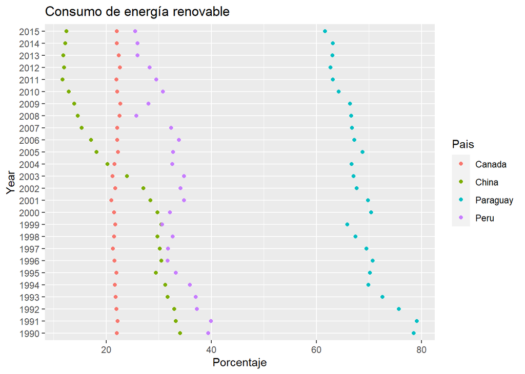

```r
ggplot(grafico_A, mapping = aes(x=Porcentaje, y=Year, color = Pais))+
  geom_point()+
  labs(title = "Consumo de energía renovable")
```

#### - Con un grafico muestre los 10 paises con mayor superfcie bosocosa promedio para los anos analizados. Debe mostrar tanto el grafico como la tabla de datos con la que se realizo el grafico.

```r
library(tidyr)
library(dplyr)
library(ggplot2)
library(scales)
library(forcats)

longer <- pivot_longer(
  datos,
  cols = -c(Pais,Codigo.Pais,Indicador),
  names_to = "Year",
  values_to = "Porcentaje",
  values_drop_na = T
)


superficie <- filter(
  longer,
  longer$Indicador == "Consumo de energía renovable (% del consumo total de energía final)"
)

superficie$Year <- gsub("[a-zA-Z ]", "", superficie$Year)
superficie$Year <- as.factor(superficie$Year)
str(superficie)
```

```
## Classes 'tbl_df', 'tbl' and 'data.frame':    6588 obs. of  5 variables:
##  $ Pais       : Factor w/ 264 levels "Afghanistan",..: 11 11 11 11 11 11 11 11 11 11 ...
##  $ Codigo.Pais: Factor w/ 264 levels "ABW","AFG","AGO",..: 1 1 1 1 1 1 1 1 1 1 ...
##  $ Indicador  : Factor w/ 2 levels "Consumo de energía renovable (% del consumo total de energía final)",..: 1 1 1 1 1 1 1 1 1 1 ...
##  $ Year       : Factor w/ 26 levels "1990","1991",..: 1 2 3 4 5 6 7 8 9 10 ...
##  $ Porcentaje : num  0.269 0.235 0.239 0.195 0.183 ...
```

```r
tabla_b <- pivot_wider(
  superficie,
  id_cols = Pais, # No toma en cuenta la variable pais
  names_from = Year,
  values_from = Porcentaje
)

grafico_B <- tabla_b %>% mutate(mean_all = rowMeans(tabla_b[-1]))

grafico_B_top_10 <- grafico_B %>%
  filter(rank(desc(mean_all))<=10)

grafico_B_top_10
```

```
## # A tibble: 10 x 28
##    Pais  `1990` `1991` `1992` `1993` `1994` `1995` `1996` `1997` `1998` `1999`
##    <fct>  <dbl>  <dbl>  <dbl>  <dbl>  <dbl>  <dbl>  <dbl>  <dbl>  <dbl>  <dbl>
##  1 Buru~   95.2   94.2   95.0   94.9   95.1   95.1   95.2   95.2   95.3   93.7
##  2 Bhut~   95.9   95.9   95.3   95.9   95.3   94.4   93.2   91.4   91.5   91.6
##  3 Cong~   92.0   95.1   95.9   96.1   96.6   96.9   97.0   97.1   96.8   97.0
##  4 Ethi~   96.6   96.7   97.7   97.2   96.9   96.6   96.4   96.2   96.1   96.2
##  5 Moza~   93.1   94.3   93.1   92.0   93.2   92.8   93.1   92.6   94.0   94.2
##  6 Nepal   95.1   94.2   94.2   93.5   92.4   91.7   91.5   90.7   90.5   88.1
##  7 Soma~   87.2   87.7   88.8   89.4   89.9   90.6   91.1   91.7   92.5   92.9
##  8 Chad    98.2   98.3   98.2   98.2   98.1   98.1   98.1   97.9   97.6   97.3
##  9 Tanz~   94.8   95.0   95.0   95.1   95.2   93.4   92.2   92.7   93.2   94.3
## 10 Ugan~   96.0   96.0   96.1   96.2   96.8   96.0   95.7   94.7   94.1   94.1
## # ... with 17 more variables: `2000` <dbl>, `2001` <dbl>, `2002` <dbl>,
## #   `2003` <dbl>, `2004` <dbl>, `2005` <dbl>, `2006` <dbl>, `2007` <dbl>,
## #   `2008` <dbl>, `2009` <dbl>, `2010` <dbl>, `2011` <dbl>, `2012` <dbl>,
## #   `2013` <dbl>, `2014` <dbl>, `2015` <dbl>, mean_all <dbl>
```

[figure not shown]

```r
ggplot(data = grafico_B_top_10,
       mapping = aes(x = fct_reorder(Pais,mean_all),
                     y = mean_all)) +
  geom_col(fill = "#07689f") +
  scale_y_continuous() +
  theme_linedraw() +
  coord_flip()+
  labs(title = "Paises con mayor superficie boscosa",
       x = "Top 10 Paises",
       y = "Promedio de porcentaje")
```

#### Ejercicio 2. El archivo DatosEducacion.csv contiene informacion de las escueles primarias de varios paises durante los años 2013 a 2019. Las variables estan por filas, los valores de dichas variables estan en forma columna por año. Nota: No olvide revisar el archivo con un bloc de notas. Cargue la tabla de datos y luego realice lo siguiente:

```r
datos <- read.csv("DatosEducacion_V2.csv", header = T, sep = ",")
```

### a) (5 pts) Convierta el dataset a uno tidy. Elimine las variables innecesarias y los valores con NA.

```r
library(tidyr)

datos <- read.csv("DatosEducacion_V2.csv", header = T, sep = ",")

wider<- pivot_wider(
  datos,
  names_from = fecha,
  values_from = valor,
  values_fill = list(valor = 0)
)
```

### b) (5 pts) Agrupe el dataset por pais y promedie los resultados, no incluya la variable fecha. Ademas, cambie los nombres de las variables a unos mas `cortos’.

```r
library(tidyr)
library(dplyr)

suma <- wider %>% mutate(mean_all = rowMeans(wider[-c(1,2,3)]))
suma <- suma[-c(2,4:10)]
#sumaPais <- suma %>% group_by(indicador)

suma_P <- pivot_wider(
  suma,
  names_from = indicador,
  values_from = mean_all
)

#str(suma_P)


suma_P <- rename(
  suma_P,
  "Repitentes" = "Cantidad de Estudiantes que repitieron",
  "Duracion en primaria" = "Duracion de la educacion primaria",
  "Alfabetizacion mayores a 15" = "Porcentaje de alfabetizacion de adultos para la poblacion mayor de 15 aÃ±os",
  "% PIB en educacion primaria" = "Gasto publico en educacion primaria como porcentaje del PIB",
  "Gasto educacion en millones USD" = "Gasto publico bruto en educacion primaria en millones de dolares",
  "% matricula" = "Porcentaje de matricula",
  "% no escolarizados" = "Porcentaje de niÃ±os no escolarizados",
  "% desercion" = "Porcentaje de desercion"
)
suma_P
```

```
## # A tibble: 226 x 10
##    pais  Repitentes `Duracion en pr~ `% desercion` `Alfabetizacion~
##    <fct>      <dbl>            <dbl>         <dbl>            <dbl>
##  1 Togo     128150.                6        13.3               9.11
##  2 India    975435.                5         6.71             10.6
##  3 Mala~    220894.                6         6.56             18.2
##  4 Solo~      6730.                6        21.0              NA
##  5 Ghana     65531.                6         7.10             11.3
##  6 Moro~    343969.                6         5.89             10.5
##  7 Libe~     17423.                6         7.65              6.90
##  8 Germ~      8854.                4        NA                NA
##  9 Anti~       126.                7        NA                14.1
## 10 Chile     38915.                6         0.273            41.4
## # ... with 216 more rows, and 5 more variables: `% matricula` <dbl>, `% no
## #   escolarizados` <dbl>, `Poblacion en edad escolar` <dbl>, `% PIB en
## #   educacion primaria` <dbl>, `Gasto educacion en millones USD` <dbl>
```

### c) (10 pts) Ejecute una Agrupacion Jerarquica con 3 clusters y muestre el dendrograma formado.

```r
library("cluster")
library("factoextra")
library("FactoMineR")

row.names(suma_P) <- suma_P$pais
```

[figure not shown]

```r
suma_P[1] <- NULL

matriz.distacias <- dist(suma_P)
modelo <- hclust(matriz.distacias, method = "complete")
plot(modelo)
rect.hclust(modelo, k = 3, border = "red")
```

### d) (10 pts) Calcule los centros de cada cluster y de una interpretacion usando el grafico de tipo radar.

```r
library("cluster")
library("factoextra")
library("FactoMineR")
library(fmsb)
# Función para encontrar el centroide de cada cluster
centroide <- function(num.cluster, datos, clusters) {
  ind <- (clusters == num.cluster)
  return(colMeans(datos[ind,]))
}

grupos <- cutree(modelo, k = 3)

centro.cluster1 <- centroide(1, suma_P, grupos)
centro.cluster1
```

```
##                      Repitentes            Duracion en primaria
##                              NA                        5.653156
##                     % desercion     Alfabetizacion mayores a 15
##                              NA                              NA
##                     % matricula              % no escolarizados
##                              NA                              NA
##       Poblacion en edad escolar     % PIB en educacion primaria
##                              NA                              NA
## Gasto educacion en millones USD
##                              NA
```

```r
centro.cluster2 <- centroide(2, suma_P, grupos)
centro.cluster2
```

```
##                      Repitentes            Duracion en primaria
##                              NA                        5.333333
##                     % desercion     Alfabetizacion mayores a 15
##                              NA                              NA
##                     % matricula              % no escolarizados
##                              NA                              NA
##       Poblacion en edad escolar     % PIB en educacion primaria
##                              NA                              NA
## Gasto educacion en millones USD
##                              NA
```

```r
centro.cluster3 <- centroide(3, suma_P, grupos)
centro.cluster3
```

```
##                      Repitentes            Duracion en primaria
##                              NA                            5.75
##                     % desercion     Alfabetizacion mayores a 15
##                              NA                              NA
##                     % matricula              % no escolarizados
##                              NA                              NA
##       Poblacion en edad escolar     % PIB en educacion primaria
##                     19694832.98                              NA
## Gasto educacion en millones USD
##                              NA
```

```r
centros <- rbind(centro.cluster1,
                 centro.cluster2,
                 centro.cluster3)

centros <- as.data.frame(centros)
maximos <- apply(centros, 2, max)
minimos <- apply(centros, 2, min)
centros <- rbind(minimos, centros)
centros <- rbind(maximos, centros)
str(centros)
```

```
## 'data.frame':    5 obs. of  9 variables:
##  $ Repitentes                     : num  NA NA NA NA NA
##  $ Duracion en primaria           : num  5.75 5.33 5.65 5.33 5.75
##  $ % desercion                    : num  NA NA NA NA NA
##  $ Alfabetizacion mayores a 15    : num  NA NA NA NA NA
##  $ % matricula                    : num  NA NA NA NA NA
##  $ % no escolarizados             : num  NA NA NA NA NA
##  $ Poblacion en edad escolar      : num  NA NA NA NA 19694833
##  $ % PIB en educacion primaria    : num  NA NA NA NA NA
##  $ Gasto educacion en millones USD: num  NA NA NA NA NA
```

```r
color <- c("red","green","blue")
radarchart(as.data.frame(centros),
           maxmin=TRUE, axistype=4,
           axislabcol="slategray4",
           centerzero=FALSE, seg=8,
           cglcol="gray67",
           pcol=color,plty=1,
           plwd=5,
           title="Comparación de clústeres")
```

[output not shown]

```r
legenda <-legend(1.5,1,
                 legend=c("Cluster 1",
                          "Cluster 2",
                          "Cluster 3"),
                 seg.len=-1.4, title="Clústeres",
                 pch=21,bty="n", lwd=3,
                 y.intersp=1, horiz=FALSE,
                 col=color)
```

[figure not shown]

### e) (24 pts) Construya una variable con el porcentaje de estudiantes que repiteron el año y otra con el gasto publico bruto si se repartiera en partes iguales a cada estudiante. Luego elimine las variables que se utilizaron para crear las 2 variables anteriores. Por ultimo, repita los 2 ejercicios anteriores con estos nuevos datos.

```r
library("tidyr")
library("dplyr")
library("cluster")
library("factoextra")
library("FactoMineR")
library("fmsb")

datos <- read.csv("DatosEducacion_V2.csv", header = T, sep = ",")

str(datos)
```

```
## 'data.frame':    6647 obs. of  5 variables:
##  $ indicador: Factor w/ 9 levels "Cantidad de Estudiantes que repitieron",..: 1 1 1 1 1 1 1 1 1 1 ...
##  $ iso3     : Factor w/ 226 levels "ABW","AFG","AGO",..: 198 198 198 198 198 198 93 93 93 93 ...
##  $ pais     : Factor w/ 226 levels "Afghanistan",..: 202 202 202 202 202 202 94 94 94 94 ...
##  $ fecha    : int  2013 2014 2015 2016 2017 2018 2013 2014 2015 2016 ...
##  $ valor    : num  253214 158276 132214 118488 117760 ...
```

```r
wider<- pivot_wider(
  datos,
  names_from = fecha,
  values_from = valor,
  values_fill = list(valor = 0)
)


suma <- wider %>% mutate(mean_all = rowMeans(wider[-c(1,2,3)]))
suma <- suma[-c(2,4:10)]


suma_P <- pivot_wider(
  suma,
  names_from = indicador,
  values_from = mean_all
)

#suma_P[is.na(suma_P)] <- 0


#str(suma_P)

suma_P <- rename(
  suma_P,
  "Repitentes" = "Cantidad de Estudiantes que repitieron",
  "Duracion en primaria" = "Duracion de la educacion primaria",
  "% Alfabetizacion mayores a 15" = "Porcentaje de alfabetizacion de adultos para la poblacion mayor de 15 aÃ±os",
  "% PIB en educacion primaria" = "Gasto publico en educacion primaria como porcentaje del PIB",
  "Gasto educacion en millones USD" = "Gasto publico bruto en educacion primaria en millones de dolares",
  "% matricula" = "Porcentaje de matricula",
  "% no escolarizados" = "Porcentaje de niÃ±os no escolarizados",
  "% desercion" = "Porcentaje de desercion"
)


tabla_P <- suma_P %>%
  mutate("% de repitentes"  = suma_P$Repitentes/suma_P$`Poblacion en edad escolar`) %>%
  mutate("Gasto por estudiante en USD"  =
           (suma_P$`Gasto educacion en millones USD`)*1000000 / suma_P$`Poblacion en edad escolar`)

tabla_P <- tabla_P[-c(2,8,10)]


tabla_P[is.na(tabla_P)] <- 0

row.names(tabla_P) <- tabla_P$pais
```

[figure not shown]

```r
tabla_P[1] <- NULL

#################### MODELO DE NUEVO  ############################
matriz.distacias <- dist(tabla_P)
modelo <- hclust(matriz.distacias, method = "complete")
plot(modelo)
rect.hclust(modelo, k = 3, border = "red")
```

```r
# Función para encontrar el centroide de cada cluster
centroide <- function(num.cluster, datos, clusters) {
  ind <- (clusters == num.cluster)
  return(colMeans(datos[ind,]))
}

grupos <- cutree(modelo, k = 3)
grupos
```

[output not shown]

[output cut: 397 more lines]

[output not shown]

```r
centro.cluster1 <- centroide(1, tabla_P, grupos)
centro.cluster1
```

```
##          Duracion en primaria                   % desercion
##                    5.62955182                    3.75049381
## % Alfabetizacion mayores a 15                   % matricula
##                   15.35961685                   42.15856090
##            % no escolarizados   % PIB en educacion primaria
##                    3.19826362                    0.36667803
##               % de repitentes   Gasto por estudiante en USD
##                    0.02289613                  554.09211259
```

```r
centro.cluster2 <- centroide(2, tabla_P, grupos)
centro.cluster2
```

```
##          Duracion en primaria                   % desercion
##                  5.857143e+00                  8.774860e-01
## % Alfabetizacion mayores a 15                   % matricula
##                  1.352760e+00                  6.810577e+01
##            % no escolarizados   % PIB en educacion primaria
##                  5.847556e-01                  8.239280e-01
##               % de repitentes   Gasto por estudiante en USD
##                  5.227354e-03                  5.963653e+03
```

```r
centro.cluster3 <- centroide(3, tabla_P, grupos)
centro.cluster3
```

```
##          Duracion en primaria                   % desercion
##                  6.000000e+00                  1.228014e-01
## % Alfabetizacion mayores a 15                   % matricula
##                  8.309813e+01                  2.856554e+01
##            % no escolarizados   % PIB en educacion primaria
##                  5.885714e-03                  2.952200e-01
##               % de repitentes   Gasto por estudiante en USD
##                  1.607889e-03                  2.064338e+04
```

```r
centros <- rbind(centro.cluster1,
                 centro.cluster2,
                 centro.cluster3)

centros <- as.data.frame(centros)
maximos <- apply(centros, 2, max)
minimos <- apply(centros, 2, min)
centros <- rbind(minimos, centros)
centros <- rbind(maximos, centros)
str(centros)
```

```
## 'data.frame':    5 obs. of  8 variables:
##  $ Duracion en primaria         : num  6 5.63 5.63 5.86 6
##  $ % desercion                  : num  3.75 0.123 3.75 0.877 0.123
##  $ % Alfabetizacion mayores a 15: num  83.1 1.35 15.36 1.35 83.1
##  $ % matricula                  : num  68.1 28.6 42.2 68.1 28.6
##  $ % no escolarizados           : num  3.19826 0.00589 3.19826 0.58476 0.00589
##  $ % PIB en educacion primaria  : num  0.824 0.295 0.367 0.824 0.295
##  $ % de repitentes              : num  0.0229 0.00161 0.0229 0.00523 0.00161
##  $ Gasto por estudiante en USD  : num  20643 554 554 5964 20643
```

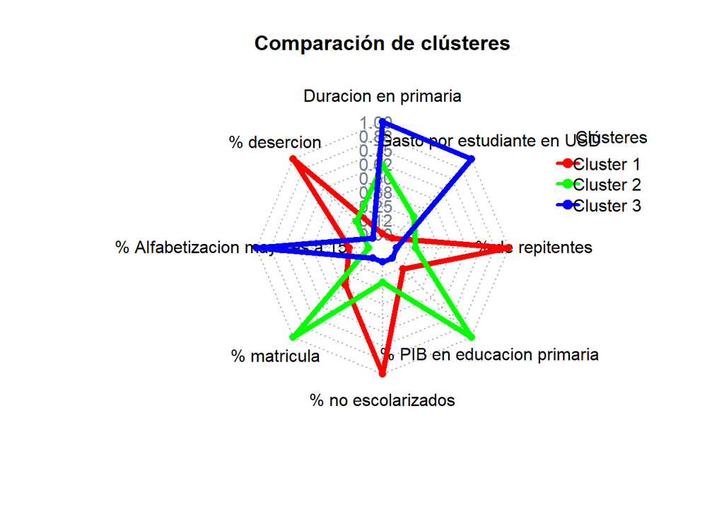

```r
color <- c("red","green","blue")
radarchart(as.data.frame(centros),
           maxmin=TRUE, axistype=4,
           axislabcol="slategray4",
           centerzero=FALSE, seg=8,
           cglcol="gray67",
           pcol=color,plty=1,
           plwd=5,
           title="Comparación de clústeres")

legenda <-legend(1.5,1,
                 legend=c("Cluster 1",
                          "Cluster 2",
                          "Cluster 3"),
                 seg.len=-1.4, title="Clústeres",
                 pch=21,bty="n", lwd=3,
                 y.intersp=1, horiz=FALSE,
                 col=color)
```